# Grupo 1: Palmeiras do JBRJ

Grupo palmeiras

2026-06-10

## Preparing

### Loading packages

```r
# Loading packages
## installed.packages("treemapify")
library(tidyverse)
library(skimr)
library(stringr)
library(stringi)
library(DescTools)
library(moments)
library(treemapify)
library(ggplot2)
library(dplyr)
library(patchwork)
```

```r
# Cleaning memory
rm(list=ls(all=TRUE))
gc()
```

```
##           used  (Mb) gc trigger  (Mb) max used  (Mb)
## Ncells 2447032 130.7    4522475 241.6  4522475 241.6
## Vcells 4185025  32.0    8388608  64.0  6824700  52.1
```

### Loading data

```r
# Database link
raw_url <- "https://raw.githubusercontent.com/jmalonso55/Applied-Statistics-for-a-Tropical-Arboretum/refs/heads/main/data/processed_data.csv"
```

```r
# Loading data
data_trab <- read.csv(raw_url, sep = ",")

# Checking
summary(data_trab)
```

```
##       sec_cant        tombo            family           genus
##  Length   :4621   Min.   :   1   Length   :4621   Length   :4621
##  N.unique : 214   1st Qu.:2145   N.unique :  82   N.unique : 460
##  N.blank  :   0   Median :4524   N.blank  :   0   N.blank  :   0
##  Min.nchar:   2   Mean   :4434   Min.nchar:   8   Min.nchar:   4
##  Max.nchar:  18   3rd Qu.:6640   Max.nchar:  16   Max.nchar:  16
##                   Max.   :9180   NAs      : 157   NAs      : 334
##       species            name          habito_pad       altura
##  Length   :4621   Length   :4621   Length   :4621   Min.   : 1.30
##  N.unique : 672   N.unique : 814   N.unique :   7   1st Qu.: 8.69
##  N.blank  :   0   N.blank  :   0   N.blank  :   0   Median :13.06
##  Min.nchar:   4   Min.nchar:   9   Min.nchar:   4   Mean   :14.28
##  Max.nchar:  17   Max.nchar:  30   Max.nchar:  13   3rd Qu.:18.54
##  NAs      : 615   NAs      : 615                    Max.   :44.35
##       dap           densidade         n_caule         multicaule
##  Min.   : 10.19   Min.   :0.1500   Min.   : 1.000   Min.   :0.0000
##  1st Qu.: 23.30   1st Qu.:0.5200   1st Qu.: 1.000   1st Qu.:0.0000
##  Median : 36.61   Median :0.5500   Median : 1.000   Median :0.0000
##  Mean   : 44.42   Mean   :0.6026   Mean   : 1.467   Mean   :0.1489
##  3rd Qu.: 60.16   3rd Qu.:0.7100   3rd Qu.: 1.000   3rd Qu.:0.0000
##  Max.   :224.54   Max.   :1.2300   Max.   :42.000   Max.   :1.0000
##     multicaule_l      rel_hd          area_basal
##  Length   :4621   Min.   :0.02199   Min.   :0.008155
##  N.unique :   2   1st Qu.:0.24821   1st Qu.:0.042635
##  N.blank  :   0   Median :0.35000   Median :0.105266
##  Min.nchar:   2   Mean   :0.38255   Mean   :0.219827
##  Max.nchar:   3   3rd Qu.:0.48179   3rd Qu.:0.284253
##                   Max.   :2.09473   Max.   :3.959837
```

```r
# Checking the data structure
glimpse(data_trab)
```

```
## Rows: 4,621
## Columns: 15
## $ sec_cant     <chr> "1A", "1A", "1A", "1A", "1A", "1A", "1A", "1A", "1A", "1A…
## $ tombo        <int> 1, 4, 5, 6, 7, 8, 9, 10, 14, 15, 17, 19, 20, 21, 22, 27, …
## $ family       <chr> "Fabaceae", "Moraceae", "Arecaceae", "Fabaceae", "Fabacea…
## $ genus        <chr> "Plathymenia", "Ficus", "Elaeis", "Haematoxylum", "Erythr…
## $ species      <chr> "reticulata", "religiosa", "guineensis", "campechianum", …
## $ name         <chr> "Plathymenia reticulata", "Ficus religiosa", "Elaeis guin…
## $ habito_pad   <chr> "Tree", "Tree", "Arborescent", "Tree", "Tree", "Tree", "T…
## $ altura       <dbl> 20.66, 23.47, 13.74, 7.16, 21.44, 18.46, 4.30, 8.84, 19.6…
## $ dap          <dbl> 78.05000, 152.79000, 32.79000, 11.62000, 71.33000, 72.570…
## $ densidade    <dbl> 0.52, 0.44, 0.54, 0.88, 0.58, 0.53, 1.21, 0.72, 0.54, 0.5…
## $ n_caule      <int> 1, 1, 1, 1, 1, 1, 3, 1, 1, 1, 2, 1, 1, 1, 2, 1, 1, 15, 1,…
## $ multicaule   <int> 0, 0, 0, 0, 0, 0, 1, 0, 0, 0, 1, 0, 0, 0, 1, 0, 0, 1, 0, …
## $ multicaule_l <chr> "No", "No", "No", "No", "No", "No", "Yes", "No", "No", "N…
## $ rel_hd       <dbl> 0.2647021, 0.1536095, 0.4190302, 0.6161790, 0.3005748, 0.…
## $ area_basal   <dbl> 0.47844905, 1.83349506, 0.08444476, 0.01060479, 0.3996081…
```

## Preprocessing the data

### Filtering database

```r
# Group 1 - Palmeiras
palmeira <- data_trab %>%
  filter(family =="Arecaceae")

#UNIQUE GENERO
unique(palmeira$genus)
```

```
##  [1] "Elaeis"          "Allagoptera"     "Roystonea"       "Euterpe"
##  [5] "Hyophorbe"       "Syagrus"         "Livistona"       "Sabal"
##  [9] "Carpentaria"     "Iriartea"        "Latania"         "Attalea"
## [13] "Dictyosperma"    "Archontophoenix" "Bentinckia"      "Phoenix"
## [17] "Astrocaryum"     "Rhopaloblaste"   "Aiphanes"        "Oenocarpus"
## [21] "Butia"           "Phoenicophorium" "Veitchia"        "Adonidia"
## [25] "Phytelephas"     "Caryota"         "Acrocomia"       "Acanthophoenix"
## [29] "Cocos"           "Dypsis"          "Calyptrocalyx"   "Oncosperma"
## [33] "Ptychosperma"    "Arenga"          "Borassus"        "Washingtonia"
## [37] "Saribus"         "Thrinax"         "Pigafetta"       "Chambeyronia"
## [41] "Areca"           "Licuala"         NA                "Mauritia"
## [45] "Verschaffeltia"  "Orania"          "Cryosophila"     "Mauritiella"
## [49] "Pritchardia"     "Linospadix"      "Coccothrinax"    "Corypha"
## [53] "Ravenea"         "Bactris"         "Manicaria"       "Copernicia"
## [57] "Wodyetia"        "Socratea"
```

## Pergunta 1: Avalie a população em termos de riqueza a nível de gênero. O arboreto é melhor caracterizado como coleção botânica ou jardim histórico?

```r
palmeira %>%
  filter(!is.na(genus)) %>%
  count(genus) %>%
  arrange(desc(n))
```

```
##              genus   n
## 1        Roystonea 540
## 2        Livistona 146
## 3          Attalea 100
## 4          Syagrus  62
## 5          Phoenix  49
## 6          Euterpe  47
## 7           Elaeis  46
## 8  Archontophoenix  41
## 9           Dypsis  33
## 10           Sabal  26
## 11       Acrocomia  20
## 12           Cocos  19
## 13     Astrocaryum  18
## 14        Mauritia  16
```

[output cut: 43 more lines]

### 🔴 Sugestão do professor

Como vimos nas aulas, sempre que possível, devemos optar por comunicar os resultados por meio de gráficos. Nesse sentido, minha sugestão é apresentar os resultados da tabela em um gráfico de barras. Além disso, procurem colocar títulos nos “code chunks”.

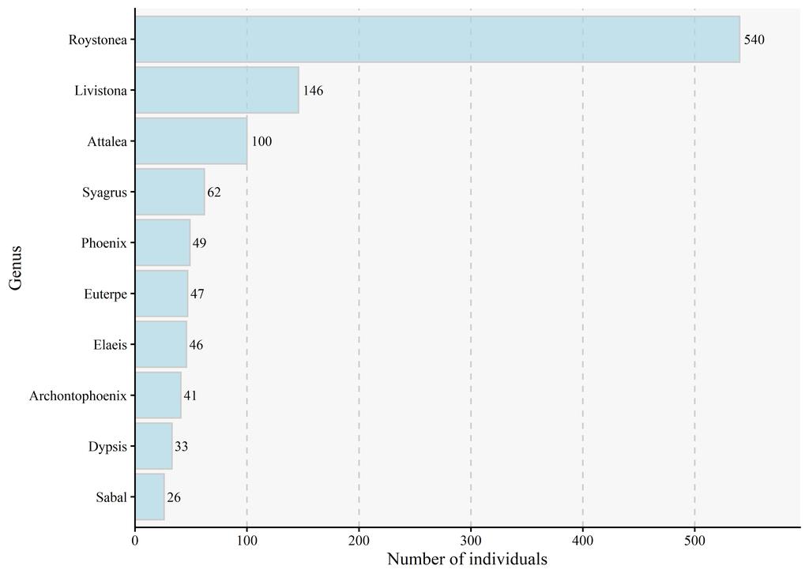

```r
# Gráfico com a frequência dos 10 gêneros mais abundantes de palmeiras
palmeira %>%
  filter(!is.na(genus)) %>%
  count(genus) %>%
  arrange(desc(n)) %>%
  slice_head(n = 10) %>%
  ggplot(aes(x = n, y = reorder(genus, n))) +
  geom_col(fill = "lightblue", color = "grey80", alpha = 0.7) +
  geom_text(aes(label = n), hjust = -0.2, family = "serif", size = 3) +
  labs(x = "Number of individuals", y = "Genus") +
  scale_x_continuous(expand = expansion(mult = c(0, 0.1))) +
  theme_classic() +
  theme(text = element_text(family = "serif"),
        panel.grid.major.x = element_line(linetype = "dashed", color = "gray80"),
        panel.background = element_rect(fill = "grey97"))
```

## Pergunta 2: Como está estruturada a população do arboreto em termos de altura e DAP? As palmeiras e árvores do arboreto estão concentradas em classes específicas de altura e DAP, ou apresentam distribuição ampla de tamanhos?

### Continuous quantitative variable

#### Para Altura

```r
# Definir classes de altura
palmeira <- palmeira %>%
    mutate(classe_alt = cut(altura, breaks = 10))

# Calcular as frequências para cada classe de altura
tab_alt <- palmeira %>%
  count(classe_alt, name = "Freq_obs") %>%
  mutate(Fre_rel = Freq_obs / sum(Freq_obs),
    Freq_acum_obs = cumsum(Freq_obs),
    Freq_acum_rel = cumsum(Fre_rel))

tab_alt <- tab_alt %>%
  bind_rows(summarise(., classe_alt = "Total",
                      Freq_obs = sum(Freq_obs),
                      Fre_rel = sum(Fre_rel),
                      Freq_acum_obs = sum(Freq_obs),
                      Freq_acum_rel = 1))

# Visualizar a tabela de frequência da altura
tab_alt
```

```
##     classe_alt Freq_obs     Fre_rel Freq_acum_obs Freq_acum_rel
## 1   (1.26,5.4]      137 0.100957996           137     0.1009580
## 2    (5.4,9.5]      193 0.142225497           330     0.2431835
## 3   (9.5,13.6]      292 0.215180545           622     0.4583640
## 4  (13.6,17.7]      215 0.158437730           837     0.6168018
## 5  (17.7,21.8]      160 0.117907148           997     0.7347089
## 6  (21.8,25.9]      152 0.112011791          1149     0.8467207
## 7    (25.9,30]       88 0.064848931          1237     0.9115696
## 8    (30,34.1]       54 0.039793662          1291     0.9513633
## 9  (34.1,38.2]       53 0.039056743          1344     0.9904200
## 10 (38.2,42.4]       13 0.009579956          1357     1.0000000
## 11       Total     1357 1.000000000          1357     1.0000000
```

```r
classes_altura <- c(  1.26, 5.4, 9.5, 13.6, 17.7,  21.8, 25.9, 30, 34.1, 38.2, 42.4)
```

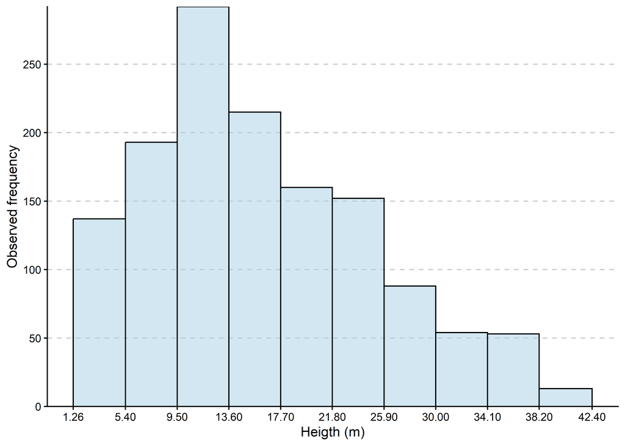

```r
# Table visualization
hist_alt<-
ggplot(palmeira, aes(x = altura)) +
  geom_histogram(bins = 10, fill = "#A8D0E6", color = "black", breaks = classes_altura, alpha = 0.5) +
  labs(x = "Heigth (m)", y = "Observed frequency") +
  scale_y_continuous(expand = c(0, 0), breaks = c(0,50,100,150,200,250)) +
  scale_x_continuous(breaks = classes_altura) +
  theme_classic() +
  theme(
    panel.grid.major.y = element_line(
      linetype = "dashed", color = "gray80")
  )
hist_alt
```

#### Para DAP

```r
# Definir classes de DAP
palmeira <- palmeira %>%
    mutate(classe_dap = cut(dap, breaks = 10))

# Calcular as frequências para cada classe de DAP
tab_dap <- palmeira %>%
  count(classe_dap, name = "Freq_obs") %>%
  mutate(Fre_rel = Freq_obs / sum(Freq_obs),
    Freq_acum_obs = cumsum(Freq_obs),
    Freq_acum_rel = cumsum(Fre_rel))

tab_alt <- tab_alt %>%
  bind_rows(summarise(., classe_dap = "Total",
                      Freq_obs = sum(Freq_obs),
                      Fre_rel = sum(Fre_rel),
                      Freq_acum_obs = sum(Freq_obs),
                      Freq_acum_rel = 1))

# Visualizar a tabela de frequência da dap
tab_dap
```

```
##     classe_dap Freq_obs     Fre_rel Freq_acum_obs Freq_acum_rel
## 1  (10.1,18.7]      134 0.098747237           134    0.09874724
## 2  (18.7,27.2]      254 0.187177598           388    0.28592483
## 3  (27.2,35.7]      195 0.143699337           583    0.42962417
## 4  (35.7,44.2]      150 0.110537951           733    0.54016212
## 5  (44.2,52.7]      121 0.089167281           854    0.62932940
## 6  (52.7,61.2]      121 0.089167281           975    0.71849668
## 7  (61.2,69.7]      179 0.131908622          1154    0.85040531
## 8  (69.7,78.2]      172 0.126750184          1326    0.97715549
## 9  (78.2,86.7]       27 0.019896831          1353    0.99705232
## 10 (86.7,95.3]        4 0.002947679          1357    1.00000000
```

```r
classes_dap <- c(10.1, 18.7, 27.2, 35.7, 44.2,52.7, 61.2, 69.7, 78.2, 86.7, 95.3)
```

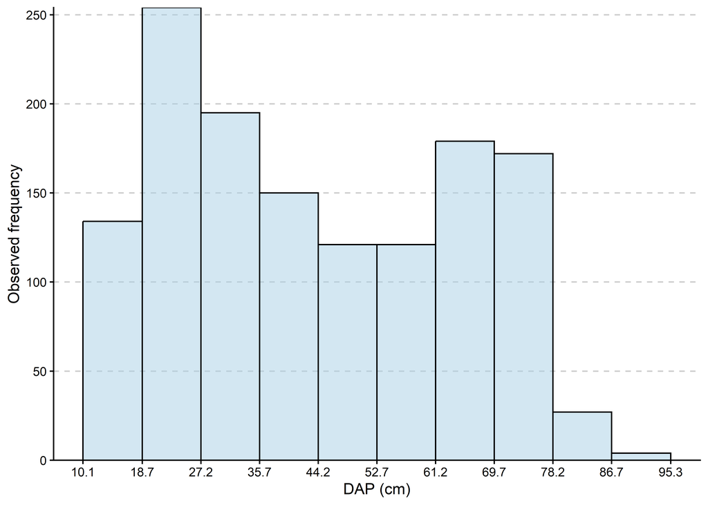

```r
# Table visualization
hist_dap<-
ggplot(palmeira, aes(x = dap)) +
  geom_histogram(bins = 10, fill = "#A8D0E6", color = "black", breaks = classes_dap, alpha = 0.5) +
  labs(x = "DAP (cm)", y = "Observed frequency") +
  scale_y_continuous(expand = c(0, 0), breaks = c(0,50,100,150,200,250,300)) +
  scale_x_continuous(breaks = classes_dap) +
  theme_classic() +
  theme(panel.grid.major.y = element_line(linetype = "dashed", color = "gray80")
  )
hist_dap
```

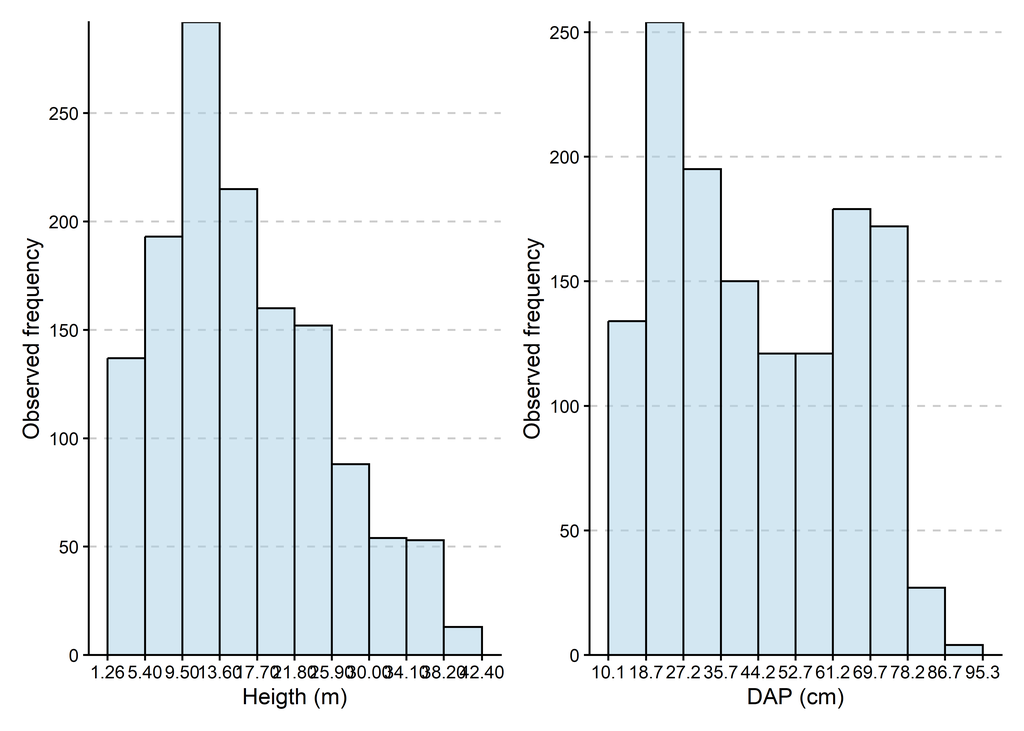

```r
# Objeto creado para armazenar graficos
hist_alt + hist_dap
```

### 🔴 Sugestão do professor

Não abordamos esse ponto em aula, mas nunca é tarde para um aprendizado adicional. No cabeçalho do *code chunk*, podemos configurar o tamanho da janela da figura. Isso resolveria o problema de sobreposição dos números no eixo. Vejam:

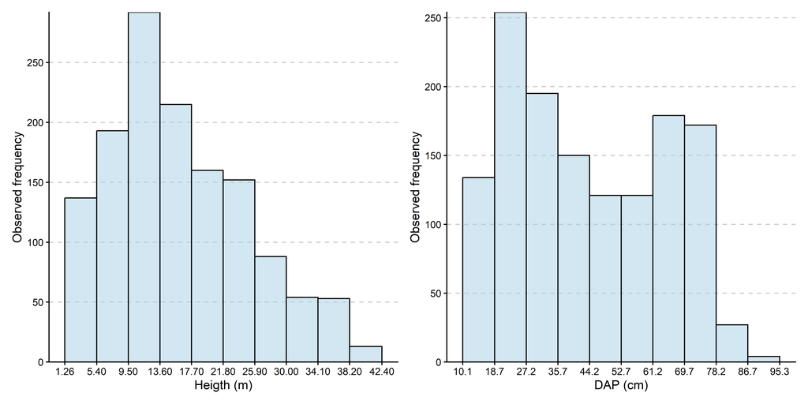

```r
# Junção dos histogramas de altura e DAP
hist_alt + hist_dap
```